# Philadelphia Shooting Victims Analysis

Anil Kumar, Shawn Thomas, Nicole Padilla

# Introduction

Gun violence is a significant issue in the city of Philadelphia. [There were 771 shooting incidents in the city in 2024 per the Philadelphia Police Department](https://www.phillypolice.com/crime-data/crime-statistics/). The goal of this project is to utilize the data provided by the Philadelphia Police Department via OpenDataPhilly on shooting incidents to build a picture of the fatal shooting incidents occurring in the city. Who is most likely to be the victim of a fatal incident (age, race, sex)? What conditions of an incident make it more likely to be fatal (wound type)? When and where are the most fatal incidents occurring (time of day/year, location)?

Understanding the trends of fatal gun violence incidents can assist in painting a clearer picture of the problem and point towards potential solutions. Understanding the time and location of the most dangerous shootings provides guidance for police on where to focus their efforts. Understanding who is most at risk of a fatal shooting guides social and health services towards populations that may benefit from interventions to assist shooting victims.

# Data Overview

The data is collected by the Philadelphia Police Department and provided via OpenDataPhilly. Below, we will load the data and gather the available variables for answering our questions.

Looking at the available fields we have a rich potential set of data to answer our questions. The age, race, sex and latino fields can provide a profile of the most frequent shooting victims. Wound can inform which types of injuries are most often fatal. Location, time and date can be used to determine when and where fatal incidents occur most often. These fields will be compared to the fatal column in order to determine fatality incidence.

```r
# Install necessary packages (run this only once)
# install.packages(c("tidyverse", "sf", "leaflet", "ggplot2", "viridis", "readr", "sp", "leaflet.extras", "readxl", "htmltools", "htmlwidgets", "shiny", "dplyr"))

#install.packages("RColorBrewer")

# Load the packages
library(tidyverse)
library(sf)
library(leaflet)
library(ggplot2)
library(viridis)
library(readr)
library(sp)
library(leaflet.extras)
library(htmltools)
library(htmlwidgets)
library(shiny)
library(dplyr)
library(RColorBrewer)


library(tidyverse)
library(readxl)
```

```r
shootings.raw = read_delim(
  "./philly_shootings.csv",
  delim=",",
  show_col_types = FALSE,
) %>% glimpse()
```

```
Rows: 16,732
Columns: 25
$ the_geom             <chr> "0101000020E61000001049CE6BA7C652C0F0FF5490EA…
$ the_geom_webmercator <chr> "0101000020110F0000790F72E295E45FC1A02823583D…
$ objectid             <dbl> 634246, 634247, 634248, 634249, 634250, 63425…
$ year                 <dbl> 2015, 2015, 2015, 2015, 2015, 2015, 2015, 201…
$ dc_key               <dbl> 201502062409, 201503069342, 201512041905, 201…
$ code                 <dbl> 3400, 400, 400, 400, 400, 400, 400, 400, 3400…
$ date_                <dttm> 2015-09-26, 2015-11-08, 2015-05-30, 2015-12-…
$ time                 <time> 05:07:00, 12:50:00, 14:11:00, 18:00:00, 19:4…
$ race                 <chr> "B", "A", "B", "B", "B", "B", "B", "B", "B", …
$ sex                  <chr> "M", "M", "M", "M", "F", "F", "F", "M", "F", …
$ age                  <dbl> 43, 36, 27, 23, 15, 21, 26, 33, 26, 43, 21, 3…
$ wound                <chr> "Chest", "Arm", "Stomach", "Leg", "Leg", "Leg…
$ officer_involved     <chr> "N", "N", "N", "N", "N", "N", "N", "N", "N", …
$ offender_injured     <chr> "N", "N", "N", "N", "N", "N", "N", "N", "N", …
$ offender_deceased    <chr> "N", "N", "N", "N", "N", "N", "N", "N", "N", …
$ location             <chr> "700 BLOCK Adams Ave", "1700 BLOCK S 5th St",…
$ latino               <dbl> 0, 0, 0, 0, 0, 0, 0, 0, 0, 0, 0, 0, 0, 0, 0, …
$ point_x              <dbl> -75.10397, -75.15405, -75.23670, -75.22840, -…
$ point_y              <dbl> 40.03060, 39.92726, 39.91765, 39.91845, 40.04…
$ dist                 <dbl> 2, 3, 12, 12, 14, 14, 14, 14, 14, 14, 14, 14,…
$ inside               <dbl> 0, 0, 0, 0, 0, 0, 0, 0, 0, 0, 0, 0, 0, 0, 0, …
$ outside              <dbl> 1, 1, 1, 1, 1, 1, 1, 1, 1, 1, 1, 1, 1, 1, 1, …
$ fatal                <dbl> 1, 0, 0, 0, 0, 0, 0, 0, 0, 0, 0, 0, 0, 0, 0, …
$ lat                  <dbl> 40.03060, 39.92726, 39.91765, 39.91845, 40.04…
$ lng                  <dbl> -75.10397, -75.15405, -75.23670, -75.22840, -…
```

# Exploratory Data Analysis

## Handling NAs

First, we look at NAs to see where we may have missing data that needs to be cleaned up. Looking at the summary of NAs a group of 153 NAs shows up across multiple columns including fatal. We will investigate those to clean them up since they will prevent us from accurately summing the fatalities.

```r
shootings.raw %>% summarise_all(~ sum(is.na(.)))
```

| the_geom | the_geom_webmercator | objectid | year | dc_key | code | date_ | time | race | sex | age | wound | officer_involved | offender_injured | offender_deceased | location | latino | point_x | point_y | dist | inside | outside | fatal | lat | lng |
| --- | --- | --- | --- | --- | --- | --- | --- | --- | --- | --- | --- | --- | --- | --- | --- | --- | --- | --- | --- | --- | --- | --- | --- | --- |
| 2 | 28 | 0 | 0 | 0 | 167 | 0 | 153 | 153 | 16 | 274 | 159 | 0 | 0 | 0 | 0 | 153 | 33 | 33 | 2 | 153 | 153 | 153 | 28 | 28 |

Based on this, it looks like certain columns, including fatal, are left blank in any incident that involves an officer. In these cases the only fatality data provided is offender deceased. However, this would leave out any other fatalities that occurred during the incident since not everyone injured in a shooting incident is necessarily an offender.

Critical data for our analysis is missing from all of these officer involved shootings - time, race, age, wound, latino and, most importantly, fatal. There are 40 fatal incidents with an officer involved for which there is incomplete data.

```r
shootings.raw %>% filter(if_any(fatal, is.na))
```

| the_geom | the_geom_webmercator | objectid | year | dc_key | code | date_ | time | race | sex | age | wound | officer_involved | offender_injured | offender_deceased | location | latino | point_x | point_y | dist | inside | outside | fatal | lat | lng |
| --- | --- | --- | --- | --- | --- | --- | --- | --- | --- | --- | --- | --- | --- | --- | --- | --- | --- | --- | --- | --- | --- | --- | --- | --- |
| 0101000020E61000004854C50D45CC52C0608D589D32F84340 | 0101000020110F0000907B2BD91FEE5FC17494271740875241 | 650840 | 2017 | 1730 | NA | 2017-11-11 | NA | NA | M | NA | NA | Y | Y | N | 1200 Block of S 29th St | NA | -75.19171 | 39.93904 | 17 | NA | NA | NA | 39.93904 | -75.19171 |
| 0101000020E61000004034364B74C752C0B06AE5D236004440 | 0101000020110F00004C69A4E1F1E55FC161BD535A22905241 | 650966 | 2024 | 2421 | NA | 2024-06-22 | NA | NA | M | NA | NA | Y | N | N | 3500 Block of F St | NA | -75.11647 | 40.00167 | 25 | NA | NA | NA | 40.00167 | -75.11647 |
| 0101000020E610000058B22AC20DCE52C050ACF89865FA4340 | 0101000020110F0000F1FB6E9B27F15FC157572AC8AF895241 | 650841 | 2017 | 1736 | NA | 2017-12-26 | NA | NA | M | NA | NA | Y | Y | N | S 49th St & Walnut St | NA | -75.21959 | 39.95623 | 18 | NA | NA | NA | 39.95623 | -75.21959 |
| 0101000020E6100000BC6B2D52BCC952C028843DA993054440 | 0101000020110F0000F60110E9D1E95FC1622E07E614965241 | 650842 | 2017 | 1737 | NA | 2017-12-27 | NA | NA | M | NA | NA | Y | Y | Y | 1900 Block of Nedro Ave | NA | -75.15212 | 40.04357 | 35 | NA | NA | NA | 40.04357 | -75.15212 |
| 0101000020E6100000C031D057DECE52C070A20F63C0F84340 | 0101000020110F0000239BB5E889F25FC1DD49C722DD875241 | 650843 | 2017 | 1708 | NA | 2017-03-29 | NA | NA | M | NA | NA | Y | Y | Y | 5600 Block of Whitby Ave | NA | -75.23231 | 39.94333 | 12 | NA | NA | NA | 39.94337 | -75.23232 |
| 0101000020E6100000841840DC3BCB52C0380AD6C645044440 | 0101000020110F0000A0DDFC635DEC5FC146D29384A2945241 | 650967 | 2020 | 2026 | NA | 2020-10-08 | NA | NA | M | NA | NA | Y | Y | Y | 5600 Block of Greene St | NA | -75.17553 | 40.03338 | 14 | NA | NA | NA | 40.03338 | -75.17553 |
| 0101000020E610000044687B29B9C752C030F9CFA2D0FE4340 | 0101000020110F00006B346EDC66E65FC192851942958E5241 | 650968 | 2020 | 2030 | NA | 2020-11-12 | NA | NA | M | NA | NA | Y | Y | Y | 1900 Block of E Hart Lane | NA | -75.12068 | 39.99074 | 24 | NA | NA | NA | 39.99074 | -75.12068 |
| 0101000020E61000004C91138B97CF52C0B80B907F9EFA4340 | 0101000020110F0000D4C5827DC4F35FC1C006C2D3EE895241 | 650969 | 2020 | 2029 | NA | 2020-10-26 | NA | NA | M | NA | NA | Y | Y | Y | 6100 Block of Locust St | NA | -75.24362 | 39.95796 | 18 | NA | NA | NA | 39.95796 | -75.24362 |
| 0101000020E6100000943FD0EBDECA52C0C8181618FCF44340 | 0101000020110F0000BFB42386BFEB5FC12138E927B1835241 | 650844 | 2018 | 1802 | NA | 2018-01-29 | NA | NA | M | NA | NA | Y | Y | Y | 1300 Block of Bigler St | NA | -75.16984 | 39.91395 | 3 | NA | NA | NA | 39.91394 | -75.16986 |
| 0101000020E610000098A6CF0ED8C752C0E0167ED3E8FE4340 | 0101000020110F0000AEC938579BE65FC1C499EC12B08E5241 | 650845 | 2018 | 1801 | NA | 2018-01-13 | NA | NA | M | NA | NA | Y | Y | N | 2800 Block of Kensington Ave | NA | -75.12256 | 39.99148 | 24 | NA | NA | NA | 39.99148 | -75.12256 |

[output cut: 143 more lines]

```r
shootings.raw %>% filter(officer_involved == 'Y')
```

| the_geom | the_geom_webmercator | objectid | year | dc_key | code | date_ | time | race | sex | age | wound | officer_involved | offender_injured | offender_deceased | location | latino | point_x | point_y | dist | inside | outside | fatal | lat | lng |
| --- | --- | --- | --- | --- | --- | --- | --- | --- | --- | --- | --- | --- | --- | --- | --- | --- | --- | --- | --- | --- | --- | --- | --- | --- |
| 0101000020E61000004854C50D45CC52C0608D589D32F84340 | 0101000020110F0000907B2BD91FEE5FC17494271740875241 | 650840 | 2017 | 1730 | NA | 2017-11-11 | NA | NA | M | NA | NA | Y | Y | N | 1200 Block of S 29th St | NA | -75.19171 | 39.93904 | 17 | NA | NA | NA | 39.93904 | -75.19171 |
| 0101000020E61000004034364B74C752C0B06AE5D236004440 | 0101000020110F00004C69A4E1F1E55FC161BD535A22905241 | 650966 | 2024 | 2421 | NA | 2024-06-22 | NA | NA | M | NA | NA | Y | N | N | 3500 Block of F St | NA | -75.11647 | 40.00167 | 25 | NA | NA | NA | 40.00167 | -75.11647 |
| 0101000020E610000058B22AC20DCE52C050ACF89865FA4340 | 0101000020110F0000F1FB6E9B27F15FC157572AC8AF895241 | 650841 | 2017 | 1736 | NA | 2017-12-26 | NA | NA | M | NA | NA | Y | Y | N | S 49th St & Walnut St | NA | -75.21959 | 39.95623 | 18 | NA | NA | NA | 39.95623 | -75.21959 |
| 0101000020E6100000BC6B2D52BCC952C028843DA993054440 | 0101000020110F0000F60110E9D1E95FC1622E07E614965241 | 650842 | 2017 | 1737 | NA | 2017-12-27 | NA | NA | M | NA | NA | Y | Y | Y | 1900 Block of Nedro Ave | NA | -75.15212 | 40.04357 | 35 | NA | NA | NA | 40.04357 | -75.15212 |
| 0101000020E6100000C031D057DECE52C070A20F63C0F84340 | 0101000020110F0000239BB5E889F25FC1DD49C722DD875241 | 650843 | 2017 | 1708 | NA | 2017-03-29 | NA | NA | M | NA | NA | Y | Y | Y | 5600 Block of Whitby Ave | NA | -75.23231 | 39.94333 | 12 | NA | NA | NA | 39.94337 | -75.23232 |
| 0101000020E6100000841840DC3BCB52C0380AD6C645044440 | 0101000020110F0000A0DDFC635DEC5FC146D29384A2945241 | 650967 | 2020 | 2026 | NA | 2020-10-08 | NA | NA | M | NA | NA | Y | Y | Y | 5600 Block of Greene St | NA | -75.17553 | 40.03338 | 14 | NA | NA | NA | 40.03338 | -75.17553 |
| 0101000020E610000044687B29B9C752C030F9CFA2D0FE4340 | 0101000020110F00006B346EDC66E65FC192851942958E5241 | 650968 | 2020 | 2030 | NA | 2020-11-12 | NA | NA | M | NA | NA | Y | Y | Y | 1900 Block of E Hart Lane | NA | -75.12068 | 39.99074 | 24 | NA | NA | NA | 39.99074 | -75.12068 |
| 0101000020E61000004C91138B97CF52C0B80B907F9EFA4340 | 0101000020110F0000D4C5827DC4F35FC1C006C2D3EE895241 | 650969 | 2020 | 2029 | NA | 2020-10-26 | NA | NA | M | NA | NA | Y | Y | Y | 6100 Block of Locust St | NA | -75.24362 | 39.95796 | 18 | NA | NA | NA | 39.95796 | -75.24362 |
| 0101000020E6100000943FD0EBDECA52C0C8181618FCF44340 | 0101000020110F0000BFB42386BFEB5FC12138E927B1835241 | 650844 | 2018 | 1802 | NA | 2018-01-29 | NA | NA | M | NA | NA | Y | Y | Y | 1300 Block of Bigler St | NA | -75.16984 | 39.91395 | 3 | NA | NA | NA | 39.91394 | -75.16986 |
| 0101000020E610000098A6CF0ED8C752C0E0167ED3E8FE4340 | 0101000020110F0000AEC938579BE65FC1C499EC12B08E5241 | 650845 | 2018 | 1801 | NA | 2018-01-13 | NA | NA | M | NA | NA | Y | Y | N | 2800 Block of Kensington Ave | NA | -75.12256 | 39.99148 | 24 | NA | NA | NA | 39.99148 | -75.12256 |

[output cut: 143 more lines]

```r
shootings.officer = shootings.raw %>% filter(officer_involved == 'Y')

shootings.officer %>% filter(offender_deceased == 'Y')
```

| the_geom | the_geom_webmercator | objectid | year | dc_key | code | date_ | time | race | sex | age | wound | officer_involved | offender_injured | offender_deceased | location | latino | point_x | point_y | dist | inside | outside | fatal | lat | lng |
| --- | --- | --- | --- | --- | --- | --- | --- | --- | --- | --- | --- | --- | --- | --- | --- | --- | --- | --- | --- | --- | --- | --- | --- | --- |
| 0101000020E6100000BC6B2D52BCC952C028843DA993054440 | 0101000020110F0000F60110E9D1E95FC1622E07E614965241 | 650842 | 2017 | 1737 | NA | 2017-12-27 | NA | NA | M | NA | NA | Y | Y | Y | 1900 Block of Nedro Ave | NA | -75.15212 | 40.04357 | 35 | NA | NA | NA | 40.04357 | -75.15212 |
| 0101000020E6100000C031D057DECE52C070A20F63C0F84340 | 0101000020110F0000239BB5E889F25FC1DD49C722DD875241 | 650843 | 2017 | 1708 | NA | 2017-03-29 | NA | NA | M | NA | NA | Y | Y | Y | 5600 Block of Whitby Ave | NA | -75.23231 | 39.94333 | 12 | NA | NA | NA | 39.94337 | -75.23232 |
| 0101000020E6100000841840DC3BCB52C0380AD6C645044440 | 0101000020110F0000A0DDFC635DEC5FC146D29384A2945241 | 650967 | 2020 | 2026 | NA | 2020-10-08 | NA | NA | M | NA | NA | Y | Y | Y | 5600 Block of Greene St | NA | -75.17553 | 40.03338 | 14 | NA | NA | NA | 40.03338 | -75.17553 |
| 0101000020E610000044687B29B9C752C030F9CFA2D0FE4340 | 0101000020110F00006B346EDC66E65FC192851942958E5241 | 650968 | 2020 | 2030 | NA | 2020-11-12 | NA | NA | M | NA | NA | Y | Y | Y | 1900 Block of E Hart Lane | NA | -75.12068 | 39.99074 | 24 | NA | NA | NA | 39.99074 | -75.12068 |
| 0101000020E61000004C91138B97CF52C0B80B907F9EFA4340 | 0101000020110F0000D4C5827DC4F35FC1C006C2D3EE895241 | 650969 | 2020 | 2029 | NA | 2020-10-26 | NA | NA | M | NA | NA | Y | Y | Y | 6100 Block of Locust St | NA | -75.24362 | 39.95796 | 18 | NA | NA | NA | 39.95796 | -75.24362 |
| 0101000020E6100000943FD0EBDECA52C0C8181618FCF44340 | 0101000020110F0000BFB42386BFEB5FC12138E927B1835241 | 650844 | 2018 | 1802 | NA | 2018-01-29 | NA | NA | M | NA | NA | Y | Y | Y | 1300 Block of Bigler St | NA | -75.16984 | 39.91395 | 3 | NA | NA | NA | 39.91394 | -75.16986 |
| 0101000020E6100000549DC8D8F8C652C070733A686DFF4340 | 0101000020110F000024EFBC3120E55FC174F4DA0C438F5241 | 650970 | 2020 | 2034 | NA | 2020-12-25 | NA | NA | M | NA | NA | Y | Y | Y | 3300 Block of Emerald St | NA | -75.10894 | 39.99553 | 24 | NA | NA | NA | 39.99553 | -75.10894 |
| 0101000020E61000007099B1A044C952C0B8F8A361DEFF4340 | 0101000020110F0000D1496B9906E95FC11CAA3C4CC08F5241 | 650850 | 2016 | 1640 | NA | 2016-11-07 | NA | NA | M | NA | NA | Y | Y | Y | 3100 Block of N 9th St | NA | -75.14481 | 39.99897 | 25 | NA | NA | NA | 39.99897 | -75.14481 |
| 0101000020E610000094FB171A05CE52C080F2697B9FF84340 | 0101000020110F0000BFDA35E718F15FC13FA36DAFB8875241 | 650855 | 2017 | 1713 | NA | 2017-05-12 | NA | NA | M | NA | NA | Y | Y | Y | 1200 Block of S 51st St | NA | -75.21906 | 39.94236 | 12 | NA | NA | NA | 39.94237 | -75.21906 |
| 0101000020E6100000F854D6B5A4C752C0C07F6C5FAE014440 | 0101000020110F00007330291F44E65FC16BF03CC3C2915241 | 650856 | 2017 | 1717 | NA | 2017-06-08 | NA | NA | M | NA | NA | Y | Y | Y | 4200 Block of Whitaker Ave | NA | -75.11943 | 40.01313 | 25 | NA | NA | NA | 40.01313 | -75.11943 |

[output cut: 30 more lines]

We can make an adjusted table, adding a total_fatality column that includes offender_deceased. It will not be usable for the questions of the profile of the most frequent shooting victims and their wound types, or the time of day of incidents, since that data is missing, but it can be used for the geolocation and date questions.

This introduces some potential bias into our data because it is possible that we are excluding non-offender fatalities. It is unknown to us if those are excluded or just did not occur. However, it is more complete than not including these 40 fatalities at all.

```r
shootings.adjusted = shootings.raw

shootings.adjusted$offender_fatal <- ifelse(shootings.raw$offender_deceased == "Y", 1, 0)

shootings.adjusted <- shootings.adjusted %>%
                      mutate(fatal = replace_na(fatal, 0))

shootings.adjusted$total_fatality <- shootings.adjusted$offender_fatal + shootings.adjusted$fatal

shootings.adjusted
```

| the_geom | the_geom_webmercator | objectid | year | dc_key | code | date_ | time | race | sex | age | wound | officer_involved | offender_injured | offender_deceased | location | latino | point_x | point_y | dist | inside | outside | fatal | lat | lng | offender_fatal | total_fatality |
| --- | --- | --- | --- | --- | --- | --- | --- | --- | --- | --- | --- | --- | --- | --- | --- | --- | --- | --- | --- | --- | --- | --- | --- | --- | --- | --- |
| 0101000020E61000001049CE6BA7C652C0F0FF5490EA034440 | 0101000020110F0000790F72E295E45FC1A02823583D945241 | 634246 | 2015 | 201502062409 | 3400 | 2015-09-26 | 05:07:00 | B | M | 43 | Chest | N | N | N | 700 BLOCK Adams Ave | 0 | -75.10397 | 40.03060 | 2 | 0 | 1 | 1 | 40.03060 | -75.10397 | 0 | 1 |
| 0101000020E6100000F01CB2FDDBC952C0F82C388BB0F64340 | 0101000020110F0000EE8D7FB407EA5FC102388C7A94855241 | 634247 | 2015 | 201503069342 | 400 | 2015-11-08 | 12:50:00 | A | M | 36 | Arm | N | N | N | 1700 BLOCK S 5th St | 0 | -75.15405 | 39.92726 | 3 | 0 | 1 | 0 | 39.92726 | -75.15405 | 0 | 0 |
| 0101000020E6100000744D4D2426CF52C0707A7E8875F54340 | 0101000020110F000031AED1DD03F35FC12129AEA037845241 | 634248 | 2015 | 201512041905 | 400 | 2015-05-30 | 14:11:00 | B | M | 27 | Stomach | N | N | N | 6900 BLOCK Elmwood Ave | 0 | -75.23670 | 39.91765 | 12 | 0 | 1 | 0 | 39.91765 | -75.23670 | 0 | 0 |
| 0101000020E6100000FC4D1B1A9ECE52C018B237C18FF54340 | 0101000020110F0000A39605CA1CF25FC1D13F0CAA54845241 | 634249 | 2015 | 201512097638 | 400 | 2015-12-11 | 18:00:00 | B | M | 23 | Leg | N | N | N | 6600 BLOCK Guyer Ave | 0 | -75.22840 | 39.91845 | 12 | 0 | 1 | 0 | 39.91845 | -75.22840 | 0 | 0 |
| 0101000020E6100000D4347A2B2ECA52C028019B5A53064440 | 0101000020110F0000AF8E494B93EA5FC12EFDE991E9965241 | 634250 | 2015 | 201514093639 | 400 | 2015-11-15 | 19:40:00 | B | F | 15 | Leg | N | N | N | 1100 BLOCK Woodlawn St | 0 | -75.15907 | 40.04942 | 14 | 0 | 1 | 0 | 40.04942 | -75.15907 | 0 | 0 |
| 0101000020E6100000D4347A2B2ECA52C028019B5A53064440 | 0101000020110F0000AF8E494B93EA5FC12EFDE991E9965241 | 634251 | 2015 | 201514093645 | 400 | 2015-11-15 | 19:40:00 | B | F | 21 | Leg | N | N | N | 1100 BLOCK Woodlawn St | 0 | -75.15907 | 40.04942 | 14 | 0 | 1 | 0 | 40.04942 | -75.15907 | 0 | 0 |
| 0101000020E6100000D4347A2B2ECA52C028019B5A53064440 | 0101000020110F0000AF8E494B93EA5FC12EFDE991E9965241 | 634252 | 2015 | 201514093646 | 400 | 2015-11-15 | 19:40:00 | B | F | 26 | Arm | N | N | N | 1100 BLOCK Woodlawn St | 0 | -75.15907 | 40.04942 | 14 | 0 | 1 | 0 | 40.04942 | -75.15907 | 0 | 0 |
| 0101000020E6100000D4347A2B2ECA52C028019B5A53064440 | 0101000020110F0000AF8E494B93EA5FC12EFDE991E9965241 | 634253 | 2015 | 201514093638 | 400 | 2015-11-15 | 19:40:00 | B | M | 33 | Leg | N | N | N | 1100 BLOCK Woodlawn St | 0 | -75.15907 | 40.04942 | 14 | 0 | 1 | 0 | 40.04942 | -75.15907 | 0 | 0 |
| 0101000020E61000008CA862C038CA52C0D874341626094440 | 0101000020110F000099E3A344A5EA5FC1AC24D58F0B9A5241 | 634254 | 2015 | 201514064691 | 3400 | 2015-08-11 | 15:13:00 | B | F | 26 | Leg | N | N | N | 2400 BLOCK 78th Ave | 0 | -75.15971 | 40.07147 | 14 | 0 | 1 | 0 | 40.07147 | -75.15971 | 0 | 0 |
| 0101000020E6100000C04C043FC4CA52C0C0C2F24F7F044440 | 0101000020110F000044BCBD3692EB5FC129DBB056E2945241 | 634255 | 2015 | 201514055173 | 400 | 2015-07-11 | 22:30:00 | B | M | 43 | Arm | N | N | N | 5300 BLOCK Wakefield St | 0 | -75.16823 | 40.03514 | 14 | 0 | 1 | 0 | 40.03514 | -75.16823 | 0 | 0 |

[output cut: 990 more lines]

```r
NA
```

```r
sum(shootings.adjusted$total_fatality)
```

```
[1] 3496
```

## Examining Data by Year

Looking at fatality totals by year we can see that partial data is included for 2025. This will obviously be skewed on an annual basis since 2025 is not complete yet. We can see here that fatal shooting incidents rose from 2015 to 2021, peaked in 2021, then fell from 2021-2024.

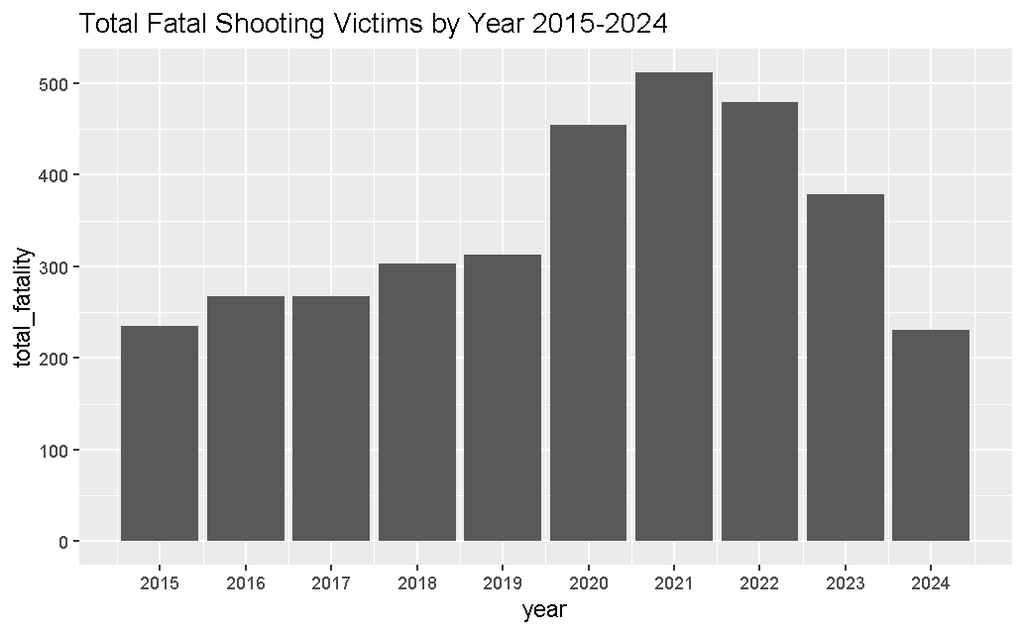

```r
fatal.byyear = aggregate(shootings.adjusted['total_fatality'], by=shootings.adjusted['year'], sum)

fatal.15to24 <- fatal.byyear %>%
  filter(year != 2025)

ggplot(data = fatal.15to24, aes(x = year, y = total_fatality)) +
  ggtitle("Total Fatal Shooting Victims by Year 2015-2024") +
  geom_col() +
  scale_x_continuous(breaks = 2015:2024)
```

## Fatal Shooting Victim Profile

```r
fatal.only <- shootings.adjusted %>%
  filter(fatal == 1)

fatal.only <- fatal.only[!is.na(fatal.only$age), ]

mean(fatal.only$age)
```

```
[1] 30.72565
```

Now, we will look at the overall distribution of shooting victim age.

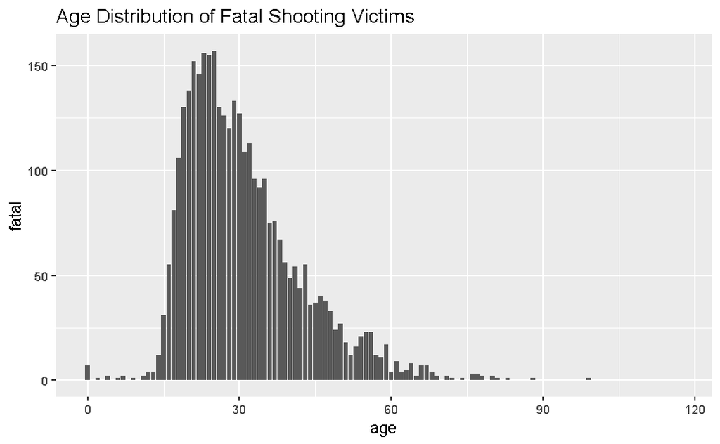

```r
ggplot(data = shootings.adjusted, aes(x = age, y = fatal)) +
  ggtitle("Age Distribution of Fatal Shooting Victims") +
  geom_col()
```

## Trends Overtime

### Average Age over Time

First, we will calculate the mean age of fatal shooting victim by year.

```r
age_avg <- fatal.only %>%
  group_by(year) %>%
  summarize(average_value = mean(age))

age_avg
```

| year | average_value |
| --- | --- |
| 2015 | 30.52790 |
| 2016 | 29.80077 |
| 2017 | 29.90734 |
| 2018 | 30.54949 |
| 2019 | 29.60065 |
| 2020 | 29.48661 |
| 2021 | 30.31809 |
| 2022 | 31.39829 |
| 2023 | 32.69022 |
| 2024 | 32.03982 |

[output cut: 1 more lines]

[figure not shown]

```r
ggplot(data = age_avg, aes(x = year, y = average_value)) +
  ggtitle("Average Age of Fatal Shooting Victims by Year 2015-2024") +
  geom_col() +
  scale_x_continuous(breaks = 2015:2024)
```

# AK - Geospatial Analysis

## Clean and prepare the data

```r
# View structure
glimpse(shootings.adjusted)
```

```
Rows: 16,732
Columns: 27
$ the_geom             <chr> "0101000020E61000001049CE6BA7C652C0F0FF5490EA…
$ the_geom_webmercator <chr> "0101000020110F0000790F72E295E45FC1A02823583D…
$ objectid             <dbl> 634246, 634247, 634248, 634249, 634250, 63425…
$ year                 <dbl> 2015, 2015, 2015, 2015, 2015, 2015, 2015, 201…
$ dc_key               <dbl> 201502062409, 201503069342, 201512041905, 201…
$ code                 <dbl> 3400, 400, 400, 400, 400, 400, 400, 400, 3400…
$ date_                <dttm> 2015-09-26, 2015-11-08, 2015-05-30, 2015-12-…
$ time                 <time> 05:07:00, 12:50:00, 14:11:00, 18:00:00, 19:4…
$ race                 <chr> "B", "A", "B", "B", "B", "B", "B", "B", "B", …
$ sex                  <chr> "M", "M", "M", "M", "F", "F", "F", "M", "F", …
$ age                  <dbl> 43, 36, 27, 23, 15, 21, 26, 33, 26, 43, 21, 3…
$ wound                <chr> "Chest", "Arm", "Stomach", "Leg", "Leg", "Leg…
$ officer_involved     <chr> "N", "N", "N", "N", "N", "N", "N", "N", "N", …
$ offender_injured     <chr> "N", "N", "N", "N", "N", "N", "N", "N", "N", …
$ offender_deceased    <chr> "N", "N", "N", "N", "N", "N", "N", "N", "N", …
$ location             <chr> "700 BLOCK Adams Ave", "1700 BLOCK S 5th St",…
$ latino               <dbl> 0, 0, 0, 0, 0, 0, 0, 0, 0, 0, 0, 0, 0, 0, 0, …
$ point_x              <dbl> -75.10397, -75.15405, -75.23670, -75.22840, -…
$ point_y              <dbl> 40.03060, 39.92726, 39.91765, 39.91845, 40.04…
$ dist                 <dbl> 2, 3, 12, 12, 14, 14, 14, 14, 14, 14, 14, 14,…
$ inside               <dbl> 0, 0, 0, 0, 0, 0, 0, 0, 0, 0, 0, 0, 0, 0, 0, …
$ outside              <dbl> 1, 1, 1, 1, 1, 1, 1, 1, 1, 1, 1, 1, 1, 1, 1, …
$ fatal                <dbl> 1, 0, 0, 0, 0, 0, 0, 0, 0, 0, 0, 0, 0, 0, 0, …
$ lat                  <dbl> 40.03060, 39.92726, 39.91765, 39.91845, 40.04…
$ lng                  <dbl> -75.10397, -75.15405, -75.23670, -75.22840, -…
$ offender_fatal       <dbl> 0, 0, 0, 0, 0, 0, 0, 0, 0, 0, 0, 0, 0, 0, 0, …
$ total_fatality       <dbl> 1, 0, 0, 0, 0, 0, 0, 0, 0, 0, 0, 0, 0, 0, 0, …
```

```r
summary(shootings.adjusted)
```

```
   the_geom         the_geom_webmercator    objectid           year
 Length:16732       Length:16732         Min.   :634246   Min.   :2015
 Class :character   Class :character     1st Qu.:638429   1st Qu.:2018
 Mode  :character   Mode  :character     Median :642612   Median :2020
                                         Mean   :642612   Mean   :2020
                                         3rd Qu.:646794   3rd Qu.:2022
                                         Max.   :650977   Max.   :2025

     dc_key               code            date_
 Min.   :1.502e+03   Min.   : 100.0   Min.   :2015-01-01 00:00:00.00
 1st Qu.:2.018e+11   1st Qu.: 300.0   1st Qu.:2018-04-02 00:00:00.00
 Median :2.020e+11   Median : 400.0   Median :2020-09-25 00:00:00.00
 Mean   :2.001e+11   Mean   : 428.5   Mean   :2020-05-14 23:53:22.39
 3rd Qu.:2.022e+11   3rd Qu.: 400.0   3rd Qu.:2022-06-27 06:00:00.00
 Max.   :2.025e+11   Max.   :3700.0   Max.   :2025-04-28 00:00:00.00
                     NA's   :167
     time              race               sex                 age
 Length:16732      Length:16732       Length:16732       Min.   :  0.00
 Class1:hms        Class :character   Class :character   1st Qu.: 21.00
 Class2:difftime   Mode  :character   Mode  :character   Median : 27.00
 Mode  :numeric                                          Mean   : 29.34
                                                         3rd Qu.: 35.00
                                                         Max.   :117.00
                                                         NA's   :274
    wound           officer_involved   offender_injured
 Length:16732       Length:16732       Length:16732
 Class :character   Class :character   Class :character
 Mode  :character   Mode  :character   Mode  :character




 offender_deceased    location             latino         point_x
 Length:16732       Length:16732       Min.   :0.000   Min.   :-75.27
 Class :character   Class :character   1st Qu.:0.000   1st Qu.:-75.19
 Mode  :character   Mode  :character   Median :0.000   Median :-75.16
                                       Mean   :0.123   Mean   :-75.16
                                       3rd Qu.:0.000   3rd Qu.:-75.13
                                       Max.   :1.000   Max.   :-74.96
                                       NA's   :153     NA's   :33
```

[output cut: 8 more lines]

```
     fatal             lat             lng         offender_fatal
 Min.   :0.0000   Min.   :39.88   Min.   :-75.27   Min.   :0.000000
 1st Qu.:0.0000   1st Qu.:39.97   1st Qu.:-75.19   1st Qu.:0.000000
 Median :0.0000   Median :39.99   Median :-75.16   Median :0.000000
 Mean   :0.2066   Mean   :39.99   Mean   :-75.16   Mean   :0.002391
 3rd Qu.:0.0000   3rd Qu.:40.02   3rd Qu.:-75.13   3rd Qu.:0.000000
 Max.   :1.0000   Max.   :40.13   Max.   :-74.96   Max.   :1.000000
                  NA's   :28      NA's   :28
 total_fatality
 Min.   :0.0000
 1st Qu.:0.0000
 Median :0.0000
 Mean   :0.2089
 3rd Qu.:0.0000
 Max.   :1.0000
```

```r
shootings.spatial  <- shootings.adjusted %>%
  filter(!is.na(lat) & !is.na(lng)) %>%
  rename(latitude = lat, longitude = lng)
```

## Convert to spatial data

```r
shootings_sf <- st_as_sf(shootings.spatial , coords = c("longitude", "latitude"), crs = 4326)
```

## Plotting Static Map

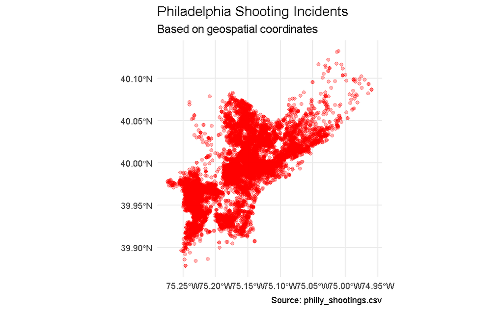

```r
ggplot(data = shootings_sf) +
  geom_sf(alpha = 0.3, color = "red") +
  theme_minimal() +
  labs(title = "Philadelphia Shooting Incidents",
       subtitle = "Based on geospatial coordinates",
       caption = "Source: philly_shootings.csv")
```

## Interactive Map Using Leaflet

```r
# Load necessary libraries
# Ensure you have these: dplyr, sf, leaflet, RColorBrewer, grDevices, htmltools, htmlwidgets, jsonlite
library(dplyr)
library(sf)
library(leaflet)
library(RColorBrewer)
library(grDevices)
library(htmltools)
library(htmlwidgets)
library(jsonlite)

# Ensure shootings_sf is an sf object and has relevant columns
# This assumes 'shootings_sf' is already loaded and processed.
# Replace the placeholder below with your actual data loading and preparation.
if (!exists("shootings_sf") || !"sf" %in% class(shootings_sf)) {
 message("Warning: 'shootings_sf' not found or not an sf object. Using dummy data for example structure.")
 # Dummy data for example structure:
 shootings_sf <- data.frame(
    year = rep(2020:2021, each = 2),
    date_ = as.Date(c("2020-01-01", "2020-02-01", "2021-01-15", "2021-03-10")),
    location = paste("Location", 1:4),
    total_fatality = c(0, 1, 0, 1),
    lat = runif(4, 39.9, 40.1),
    lng = runif(4, -75.2, -75.1)
 ) %>%
 st_as_sf(coords = c("lng", "lat"), crs = 4326)
}

if (!"total_fatality" %in% names(shootings_sf) || !"year" %in% names(shootings_sf) || !"date_" %in% names(shootings_sf) || !"location" %in% names(shootings_sf) ) {
  stop("shootings_sf is missing one or more required columns: year, date_, location, total_fatality.")
}

if (!"unique_id" %in% names(shootings_sf)) {
  shootings_sf <- shootings_sf %>%
    dplyr::mutate(unique_id = paste0("marker-", dplyr::row_number(), "-", year))
}

# Create unique list of years
years <- if ("year" %in% names(shootings_sf)) sort(unique(shootings_sf$year)) else character(0)

# Create color palette
if (length(years) > 0) {
  if (length(years) <= 8) {
    year_palette_colors <- RColorBrewer::brewer.pal(max(3, length(years)), "Dark2")
    if (length(years) < 3) {
      year_palette_colors <- year_palette_colors[1:length(years)]
    }
  } else {
    year_palette_colors <- grDevices::colorRampPalette(RColorBrewer::brewer.pal(min(length(years), 9), "Dark2"))(length(years))
  }
  year_colors <- leaflet::colorFactor(palette = year_palette_colors, domain = years)
} else {
  year_colors <- NULL
  warning("Year column not found or no unique years in shootings_sf. Map may not display year layers correctly.")
}

# Create base map centered on Philadelphia
center_lon <- -75.1652
center_lat <- 39.9526

m <- leaflet::leaflet(shootings_sf) %>%
  leaflet::setView(lng = center_lon, lat = center_lat, zoom = 11) %>%
  leaflet::addProviderTiles(leaflet::providers$CartoDB.Positron) %>%
  htmlwidgets::onRender("function(el, x) { el.classList.add('safegraph-map'); }")

# Add circle markers by year
if (length(years) > 0 && !is.null(year_colors)) {
  for (yr in years) {
    year_data <- shootings_sf %>% dplyr::filter(year == yr)
    if (nrow(year_data) > 0) {
      m <- m %>% leaflet::addCircleMarkers(
        data = year_data,
        radius = 5,
        color = ~year_colors(year),
        fillOpacity = 0.7,
        stroke = FALSE,
        group = as.character(yr),
        popup = ~paste(
          "<b>Year:</b>", htmltools::htmlEscape(year), "<br>",
          "<b>Date:</b>", htmltools::htmlEscape(date_), "<br>",
          "<b>Location:</b>", htmltools::htmlEscape(location), "<br>",
          "<b>Fatality:</b>", ifelse(total_fatality > 0, "Yes", "No")
        ),
        layerId = ~unique_id
      )
    }
  }
}

# Add layer control
if (length(years) > 0) {
  m <- m %>% leaflet::addLayersControl(
    overlayGroups = as.character(years),
    options = leaflet::layersControlOptions(collapsed = FALSE)
  )
}

# JavaScript for a single "Select/Deselect All" toggle button using paste0
year_groups_json_str <- jsonlite::toJSON(as.character(years)) # Prepare JSON string once

select_toggle_js <- paste0(
  "function(el, x, data) {\n",
  "  setTimeout(function() {\n",
  "    var yearGroups = ", year_groups_json_str, ";\n",
  "    if (!yearGroups || yearGroups.length === 0) { console.warn('No year groups for toggle button.'); return; }\n",
  "    var layersControlContainer = el.querySelector('.leaflet-control-layers-overlays');\n",
  "    if (!layersControlContainer) { console.warn('Layers control container not found for toggle button.'); return; }\n",
  "\n",
  "    var toggleButton = L.DomUtil.create('button', 'leaflet-control-layers-selector safegraph-button');\n",
  "    toggleButton.style.marginBottom = '10px';\n",
  "\n",
  "    function getCurrentAllCheckedState() {\n",
  "      if (yearGroups.length === 0) return false;\n",
  "      for (var i = 0; i < yearGroups.length; i++) {\n",
  "        var groupStr = String(yearGroups[i]);\n",
  "        var checkbox = layersControlContainer.querySelector('input[type=\"checkbox\"][value=\"' + groupStr + '\"]');\n",
  "        if (!checkbox || !checkbox.checked) return false;\n",
  "      }\n",
  "      return true;\n",
  "    }\n",
  "\n",
  "    function updateButtonText() {\n",
  "      if (getCurrentAllCheckedState()) {\n",
  "        toggleButton.innerHTML = 'Deselect All Years';\n",
  "      } else {\n",
  "        toggleButton.innerHTML = 'Select All Years';\n",
  "      }\n",
  "    }\n",
  "\n",
  "    toggleButton.onclick = function() {\n",
  "      var currentlyAllChecked = getCurrentAllCheckedState();\n",
  "      var targetState = !currentlyAllChecked;\n",
  "      yearGroups.forEach(function(group) {\n",
  "        var groupStr = String(group);\n",
  "        var checkbox = layersControlContainer.querySelector('input[type=\"checkbox\"][value=\"' + groupStr + '\"]');\n",
  "        if (checkbox) {\n",
  "          if (checkbox.checked !== targetState) {\n",
  "            checkbox.click();\n",
  "          }\n",
  "        }\n",
  "      });\n",
  "      updateButtonText();\n",
  "    };\n",
  "\n",
  "    layersControlContainer.parentNode.insertBefore(toggleButton, layersControlContainer);\n",
  "    updateButtonText(); /* Set initial button text */\n",
  "  }, 250);\n",
  "}\n"
)

m <- m %>% htmlwidgets::onRender(select_toggle_js)

# Add legend
if (length(years) > 0 && !is.null(year_colors)) {
  m <- m %>% leaflet::addLegend(
    position = "bottomlefts",
    pal = year_colors,
    values = shootings_sf$year,
    title = "Shooting Year",
    opacity = 1
  )
}
```

[output not shown]